# Titanic survivors decision tree

# Introduction

In this report I will create a decision tree to see which factors are useful in predicting whether or not a passenger on the titanic survived.

```r
library(rpart) # to create the tree
library(rpart.plot) # to plot the tree
library(splitstackshape) # to force stratification on test and training sets
library(tidyverse)

titanic_set <- read_csv('data/titanic_decision_tree_data.csv')
# create a vector of all the row numbers randomised
shuffle_index <- sample(1:nrow(titanic_set))

# shuffle the data so class order isn't in order - need this for training/testing split later on
titanic_set <- titanic_set[shuffle_index, ]
```

# Data cleaning

Data currently contains several variables that will not be useful in model building, as well as missing data and variables that would be better suited as factors (with interpretable levels.

```r
titanic_clean <- titanic_set %>%
  filter(!is.na(survived)) %>%  # remove passengers without a survived flag
  # turn important variables into factors
  mutate(across(c(sex, pclass, embarked), as.factor)) %>%
  # create an age_status variable which groups passengers into children and adults
  mutate(age_status = if_else(age <= 16, "child", "adult"), .after = age) %>%
  # make class and survived , variables more interpretable
  mutate(class = factor(pclass, levels = c(3,2,1), labels = c("Lower", "Middle", "Upper")),
         survived_flag = factor(survived, levels = c(0,1), labels = c("No", "Yes")),
         port_embarked = factor(embarked, levels = c("S", "C", "Q"), labels = c("Southampton", "Cherbourg", "Queenstown"))) %>%
  select(-c(1, passenger_id, name, ticket, fare, cabin)) %>% # drop the unhelpful variables
  drop_na()
```

# Data visualisation

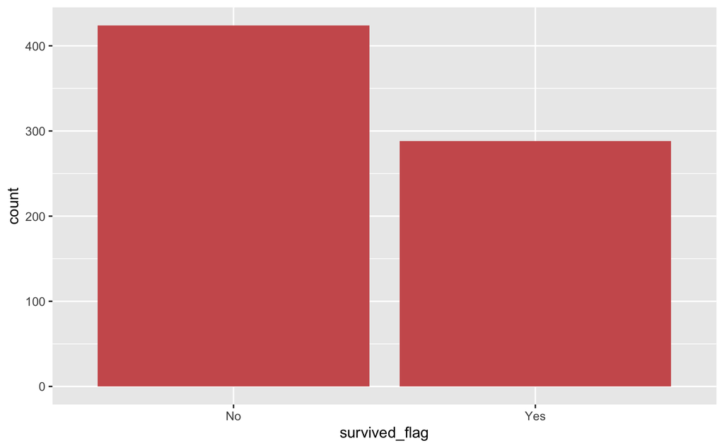

```r
titanic_clean %>%
  ggplot(aes(x = survived_flag)) +
  geom_bar(fill = "indianred")
```

We can see here that around 280 passengers survived vs over 400 who did not.

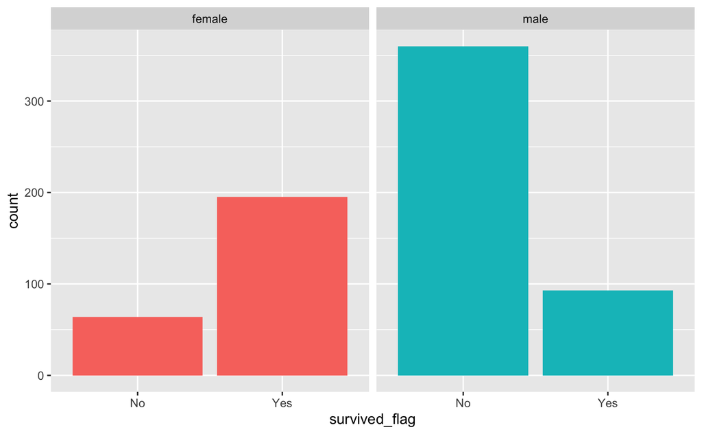

```r
titanic_clean %>%
  ggplot(aes(x = survived_flag)) +
  geom_bar(aes(fill = sex), show.legend = F) +
  facet_wrap(~ sex)
```

This bar chart shows that women were more likely to survive than men.

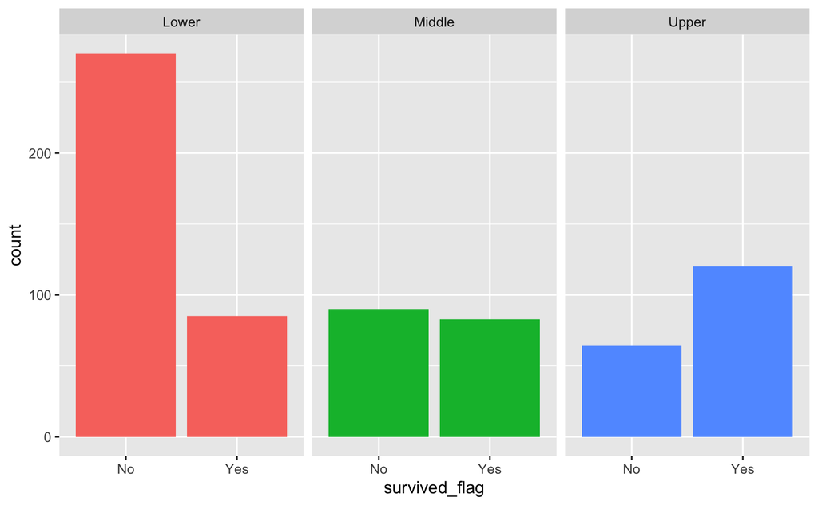

```r
titanic_clean %>%
  ggplot(aes(x = survived_flag)) +
  geom_bar(aes(fill = class), show.legend = F) +
  facet_wrap(~ class)
```

Being lower class meant a much higher chance of not surviving.

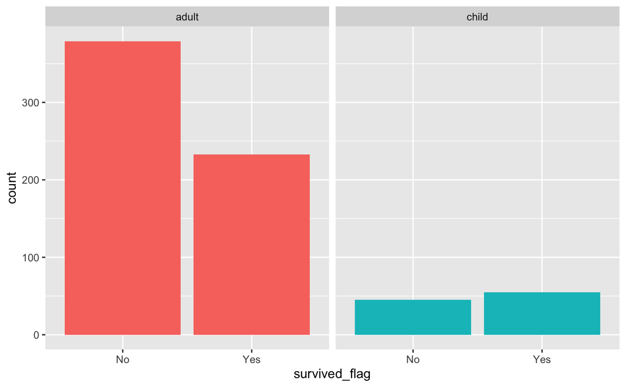

```r
titanic_clean %>%
  ggplot(aes(x = survived_flag)) +
  geom_bar(aes(fill = age_status), show.legend = F) +
  facet_wrap(~ age_status)
```

Much better odds of surviving if you were a child.

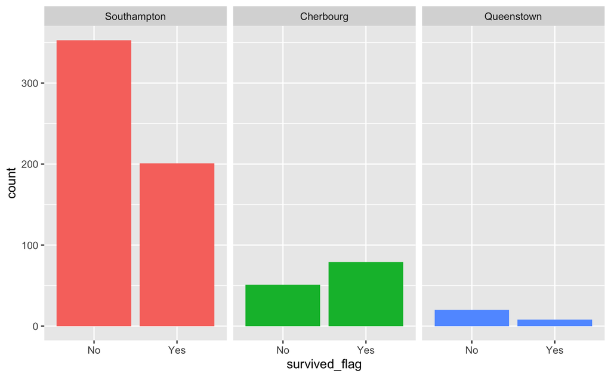

```r
titanic_clean %>%
  ggplot(aes(x = survived_flag)) +
  geom_bar(aes(fill = port_embarked), show.legend = F) +
  facet_wrap(~ port_embarked)
```

Most passengers boarded at Southampton, and these were more likely to die. Let’s see proportions.

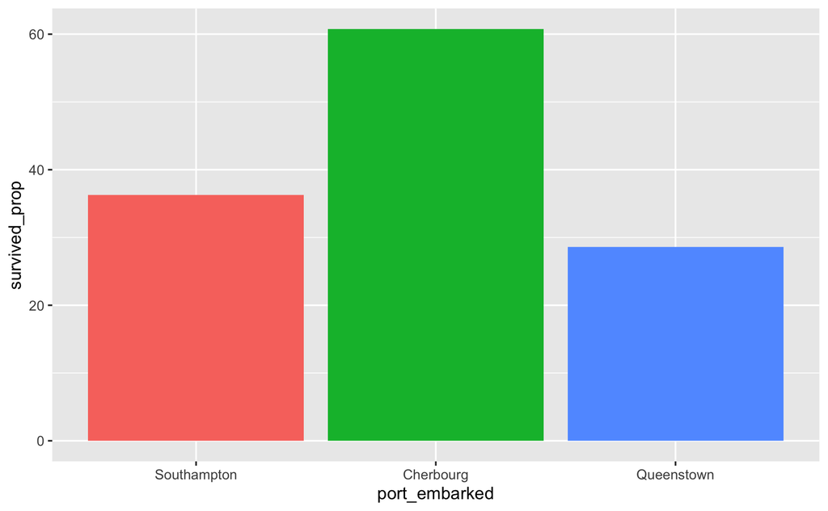

```r
titanic_clean %>%
  group_by(port_embarked) %>%
  summarise(
    prop = n()/nrow(titanic_clean) * 100,
    n_survived = sum(survived[survived_flag == "Yes"]),
    n_total = n(),
    survived_prop = n_survived/n_total * 100) %>%
  ggplot(aes(x = port_embarked, y = survived_prop)) +
  geom_col(aes(fill = port_embarked), show.legend = F)
```

Passengers who boarded in France were most likely to survive, then those from England, then Ireland.

# Model preparation

## Create test and train sets

```r
# set the random seed number to keep interpretations of model consistent with model itself
set.seed(3)

n_data <- nrow(titanic_clean)

# create a test sample index
test_index <- sample(1:n_data, size = n_data*0.2)

# create test set
titanic_test  <- slice(titanic_clean, test_index)

# create training set
titanic_train <- slice(titanic_clean, -test_index)

# check balanced sets
titanic_test %>%
 janitor::tabyl(survived_flag)
```

```
 survived_flag  n   percent
            No 81 0.5704225
           Yes 61 0.4295775
```

```r
titanic_train %>%
  janitor::tabyl(survived_flag)
```

```
 survived_flag   n   percent
            No 343 0.6017544
           Yes 227 0.3982456
```

Proportions are not so similar between sets.

### Force stratification

```r
sets <- stratified(titanic_clean, group = c("survived_flag", "sex", "class", "age_status"), bothSets = TRUE, size = 0.2)

titanic_test <- sets$SAMP1
titanic_train <- sets$SAMP2

nrow(titanic_test)
```

```
[1] 142
```

```r
nrow(titanic_train)
```

```
[1] 570
```

```r
titanic_test %>%
 janitor::tabyl(survived_flag)
```

```
 survived_flag  n  percent
            No 83 0.584507
           Yes 59 0.415493
```

```r
titanic_train %>%
  janitor::tabyl(survived_flag)
```

```
 survived_flag   n   percent
            No 341 0.5982456
           Yes 229 0.4017544
```

Survived proportions are much more similar between sets now.

# Decision tree

```r
titanic_fitted
```

[output not shown]

```
n= 570

node), split, n, loss, yval, (yprob)
      * denotes terminal node

1) root 570 229 No (0.5982456 0.4017544)
  2) survived< 0.5 341   0 No (1.0000000 0.0000000) *
  3) survived>=0.5 229   0 Yes (0.0000000 1.0000000) *
```